# WEEK 14 IP: PART 1 & 2

Joy Kiriba

# 1) Defining the question

## a) Specifying the data analytic question

`Use unsupervised learning techniques to get insights from the given data set to help create marketing strategies that would lead to the highest number of sales.`

## b) Defining the metric of success

``The project will be a success when we are able to create marketing strategies that lead to the highest number of sales.```

## c) Understanding the context

`You are a Data analyst at Carrefour Kenya and are currently undertaking a project that will inform the marketing department on the most relevant marketing strategies that will result in the highest no. of sales (total price including tax). Your project has been divided into four parts where you'll explore a recent marketing dataset by performing various unsupervised learning techniques and later providing recommendations based on your insights.`

## d) Recording the experimental design

`The process will entail:`

- Define the question, the metric for success, the context, experimental design taken.
- Read and explore the given dataset.
- Define the appropriateness of the available data to answer the given question.
- Find and deal with outliers, anomalies, and missing data within the dataset.
- Perform univariate and bivariate analysis recording my observations.
- Implement the solution.
- Challenge the solution.
- Follow up questions.

## e) Data relevance

`The dataset used can be found here:`

[Marketing dataset] (http://bit.ly/CarreFourDataset)

# 2) Reading data

```r
#loading our dataset

data <- read.csv('Sales.Data.csv')
head(data)
```

```
##    Invoice.ID Branch Customer.type Gender           Product.line Unit.price
## 1 750-67-8428      A        Member Female      Health and beauty      74.69
## 2 226-31-3081      C        Normal Female Electronic accessories      15.28
## 3 631-41-3108      A        Normal   Male     Home and lifestyle      46.33
## 4 123-19-1176      A        Member   Male      Health and beauty      58.22
## 5 373-73-7910      A        Normal   Male      Sports and travel      86.31
## 6 699-14-3026      C        Normal   Male Electronic accessories      85.39
##   Quantity     Tax      Date  Time     Payment   cogs gross.margin.percentage
## 1        7 26.1415  1/5/2019 13:08     Ewallet 522.83                4.761905
## 2        5  3.8200  3/8/2019 10:29        Cash  76.40                4.761905
## 3        7 16.2155  3/3/2019 13:23 Credit card 324.31                4.761905
## 4        8 23.2880 1/27/2019 20:33     Ewallet 465.76                4.761905
## 5        7 30.2085  2/8/2019 10:37     Ewallet 604.17                4.761905
## 6        7 29.8865 3/25/2019 18:30     Ewallet 597.73                4.761905
##   gross.income Rating    Total
## 1      26.1415    9.1 548.9715
## 2       3.8200    9.6  80.2200
## 3      16.2155    7.4 340.5255
## 4      23.2880    8.4 489.0480
## 5      30.2085    5.3 634.3785
## 6      29.8865    4.1 627.6165
```

# 3) Checking the data

```r
# Viewing the top 6 entries
head(data)
```

```
##    Invoice.ID Branch Customer.type Gender           Product.line Unit.price
## 1 750-67-8428      A        Member Female      Health and beauty      74.69
## 2 226-31-3081      C        Normal Female Electronic accessories      15.28
## 3 631-41-3108      A        Normal   Male     Home and lifestyle      46.33
## 4 123-19-1176      A        Member   Male      Health and beauty      58.22
## 5 373-73-7910      A        Normal   Male      Sports and travel      86.31
## 6 699-14-3026      C        Normal   Male Electronic accessories      85.39
##   Quantity     Tax      Date  Time     Payment   cogs gross.margin.percentage
## 1        7 26.1415  1/5/2019 13:08     Ewallet 522.83                4.761905
## 2        5  3.8200  3/8/2019 10:29        Cash  76.40                4.761905
## 3        7 16.2155  3/3/2019 13:23 Credit card 324.31                4.761905
## 4        8 23.2880 1/27/2019 20:33     Ewallet 465.76                4.761905
## 5        7 30.2085  2/8/2019 10:37     Ewallet 604.17                4.761905
## 6        7 29.8865 3/25/2019 18:30     Ewallet 597.73                4.761905
##   gross.income Rating    Total
## 1      26.1415    9.1 548.9715
## 2       3.8200    9.6  80.2200
## 3      16.2155    7.4 340.5255
## 4      23.2880    8.4 489.0480
## 5      30.2085    5.3 634.3785
## 6      29.8865    4.1 627.6165
```

```r
#Data types of the columns
str(data)
```

```
## 'data.frame':    1000 obs. of  16 variables:
##  $ Invoice.ID             : chr  "750-67-8428" "226-31-3081" "631-41-3108" "123-19-1176" ...
##  $ Branch                 : chr  "A" "C" "A" "A" ...
##  $ Customer.type          : chr  "Member" "Normal" "Normal" "Member" ...
##  $ Gender                 : chr  "Female" "Female" "Male" "Male" ...
##  $ Product.line           : chr  "Health and beauty" "Electronic accessories" "Home and lifestyle" "Health and beauty" ...
##  $ Unit.price             : num  74.7 15.3 46.3 58.2 86.3 ...
##  $ Quantity               : int  7 5 7 8 7 7 6 10 2 3 ...
##  $ Tax                    : num  26.14 3.82 16.22 23.29 30.21 ...
##  $ Date                   : chr  "1/5/2019" "3/8/2019" "3/3/2019" "1/27/2019" ...
##  $ Time                   : chr  "13:08" "10:29" "13:23" "20:33" ...
##  $ Payment                : chr  "Ewallet" "Cash" "Credit card" "Ewallet" ...
##  $ cogs                   : num  522.8 76.4 324.3 465.8 604.2 ...
##  $ gross.margin.percentage: num  4.76 4.76 4.76 4.76 4.76 ...
##  $ gross.income           : num  26.14 3.82 16.22 23.29 30.21 ...
##  $ Rating                 : num  9.1 9.6 7.4 8.4 5.3 4.1 5.8 8 7.2 5.9 ...
##  $ Total                  : num  549 80.2 340.5 489 634.4 ...
```

```r
#Statistical summary of the data set
summary(data)
```

```
##   Invoice.ID           Branch          Customer.type         Gender
##  Length:1000        Length:1000        Length:1000        Length:1000
##  Class :character   Class :character   Class :character   Class :character
##  Mode  :character   Mode  :character   Mode  :character   Mode  :character
##
##
##
##  Product.line         Unit.price       Quantity          Tax
##  Length:1000        Min.   :10.08   Min.   : 1.00   Min.   : 0.5085
##  Class :character   1st Qu.:32.88   1st Qu.: 3.00   1st Qu.: 5.9249
##  Mode  :character   Median :55.23   Median : 5.00   Median :12.0880
##                     Mean   :55.67   Mean   : 5.51   Mean   :15.3794
##                     3rd Qu.:77.94   3rd Qu.: 8.00   3rd Qu.:22.4453
##                     Max.   :99.96   Max.   :10.00   Max.   :49.6500
##      Date               Time             Payment               cogs
##  Length:1000        Length:1000        Length:1000        Min.   : 10.17
##  Class :character   Class :character   Class :character   1st Qu.:118.50
##  Mode  :character   Mode  :character   Mode  :character   Median :241.76
##                                                           Mean   :307.59
##                                                           3rd Qu.:448.90
##                                                           Max.   :993.00
##  gross.margin.percentage  gross.income         Rating           Total
##  Min.   :4.762           Min.   : 0.5085   Min.   : 4.000   Min.   :  10.68
##  1st Qu.:4.762           1st Qu.: 5.9249   1st Qu.: 5.500   1st Qu.: 124.42
##  Median :4.762           Median :12.0880   Median : 7.000   Median : 253.85
##  Mean   :4.762           Mean   :15.3794   Mean   : 6.973   Mean   : 322.97
##  3rd Qu.:4.762           3rd Qu.:22.4453   3rd Qu.: 8.500   3rd Qu.: 471.35
##  Max.   :4.762           Max.   :49.6500   Max.   :10.000   Max.   :1042.65
```

```r
#checking the number of entries and attributes
dim(data)
```

```
## [1] 1000   16
```

```r
#checking the class of our object
class(data)
```

```
## [1] "data.frame"
```

# 4) Cleaning data

```r
#Changing column names to lower case
names(data) <- tolower(names(data))
head(data)
```

```
##    invoice.id branch customer.type gender           product.line unit.price
## 1 750-67-8428      A        Member Female      Health and beauty      74.69
## 2 226-31-3081      C        Normal Female Electronic accessories      15.28
## 3 631-41-3108      A        Normal   Male     Home and lifestyle      46.33
## 4 123-19-1176      A        Member   Male      Health and beauty      58.22
## 5 373-73-7910      A        Normal   Male      Sports and travel      86.31
## 6 699-14-3026      C        Normal   Male Electronic accessories      85.39
##   quantity     tax      date  time     payment   cogs gross.margin.percentage
## 1        7 26.1415  1/5/2019 13:08     Ewallet 522.83                4.761905
## 2        5  3.8200  3/8/2019 10:29        Cash  76.40                4.761905
## 3        7 16.2155  3/3/2019 13:23 Credit card 324.31                4.761905
## 4        8 23.2880 1/27/2019 20:33     Ewallet 465.76                4.761905
## 5        7 30.2085  2/8/2019 10:37     Ewallet 604.17                4.761905
## 6        7 29.8865 3/25/2019 18:30     Ewallet 597.73                4.761905
##   gross.income rating    total
## 1      26.1415    9.1 548.9715
## 2       3.8200    9.6  80.2200
## 3      16.2155    7.4 340.5255
## 4      23.2880    8.4 489.0480
## 5      30.2085    5.3 634.3785
## 6      29.8865    4.1 627.6165
```

```r
#dropping the invoice id column
data$invoice.id <- NULL
dim(data)
```

```
## [1] 1000   15
```

```r
#checking for missing data
colSums(is.na(data))
```

```
##                  branch           customer.type                  gender
##                       0                       0                       0
##            product.line              unit.price                quantity
##                       0                       0                       0
##                     tax                    date                    time
##                       0                       0                       0
##                 payment                    cogs gross.margin.percentage
##                       0                       0                       0
##            gross.income                  rating                   total
##                       0                       0                       0
```

```r
#checking for duplicates
anyDuplicated(data)
```

```
## [1] 0
```

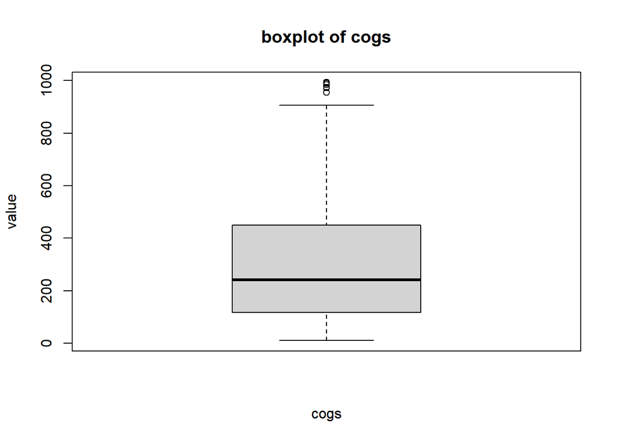

```r
#checking for outliers
#num.cols <- cogs,gross.margin.percentage, gross.income, rating, total,unit.price, quantity, tax
boxplot(data$cogs, main='boxplot of cogs', xlab='cogs', ylab='value')
```

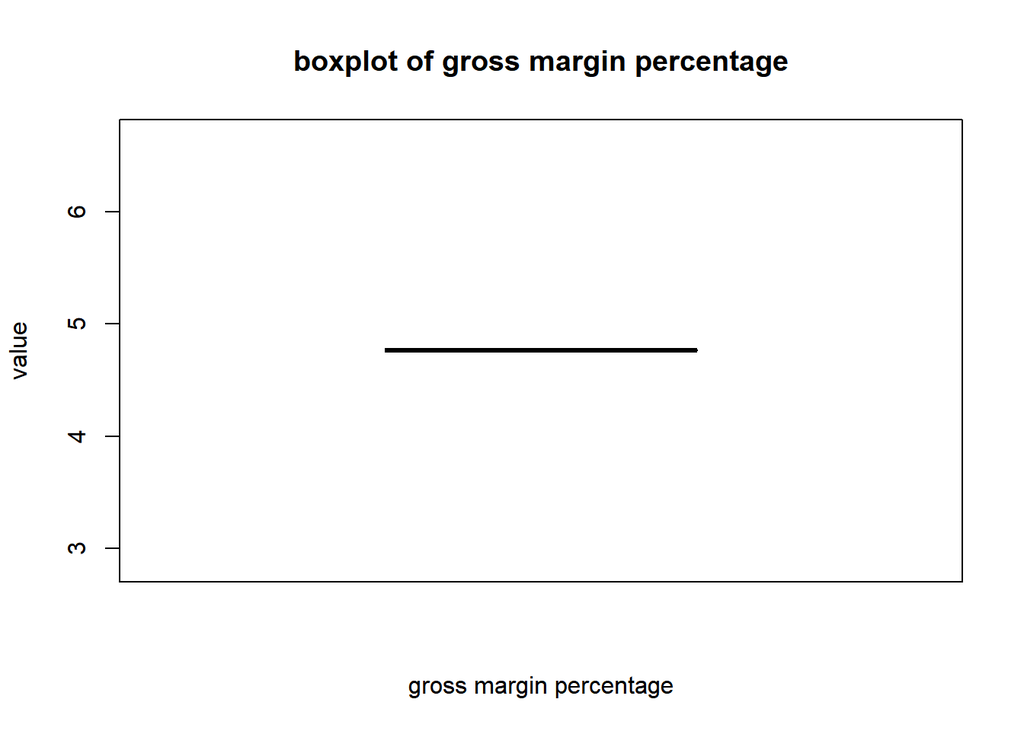

```r
boxplot(data$gross.margin.percentage, main='boxplot of gross margin percentage', xlab='gross margin percentage', ylab='value')
```

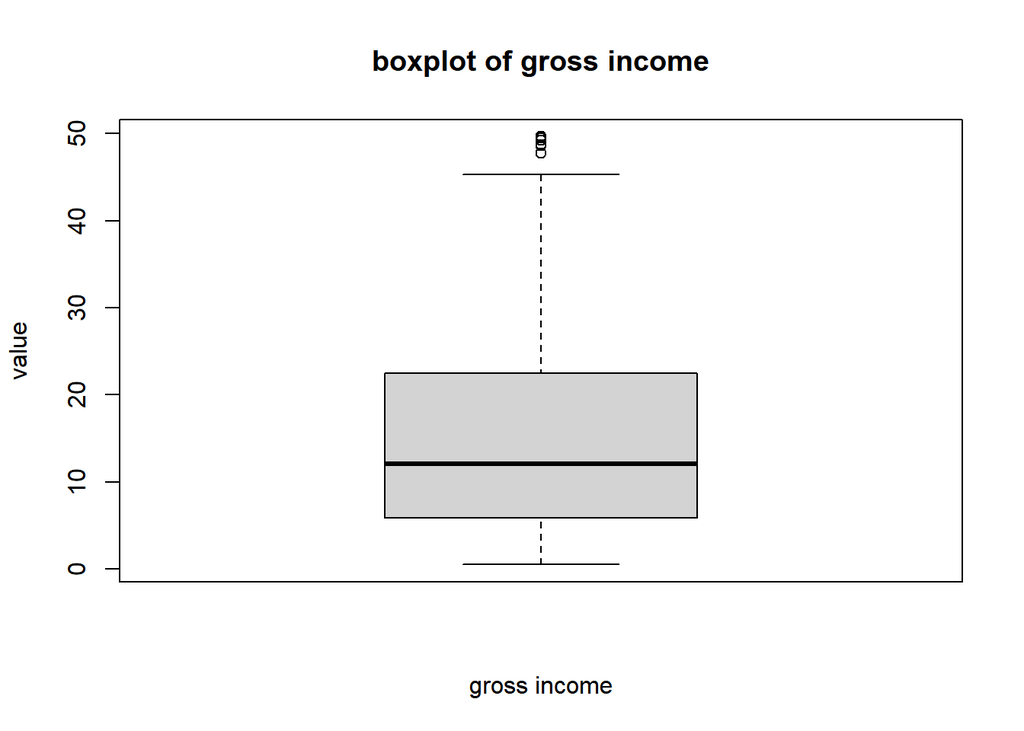

```r
boxplot(data$gross.income, main='boxplot of gross income', xlab='gross income', ylab='value')
```

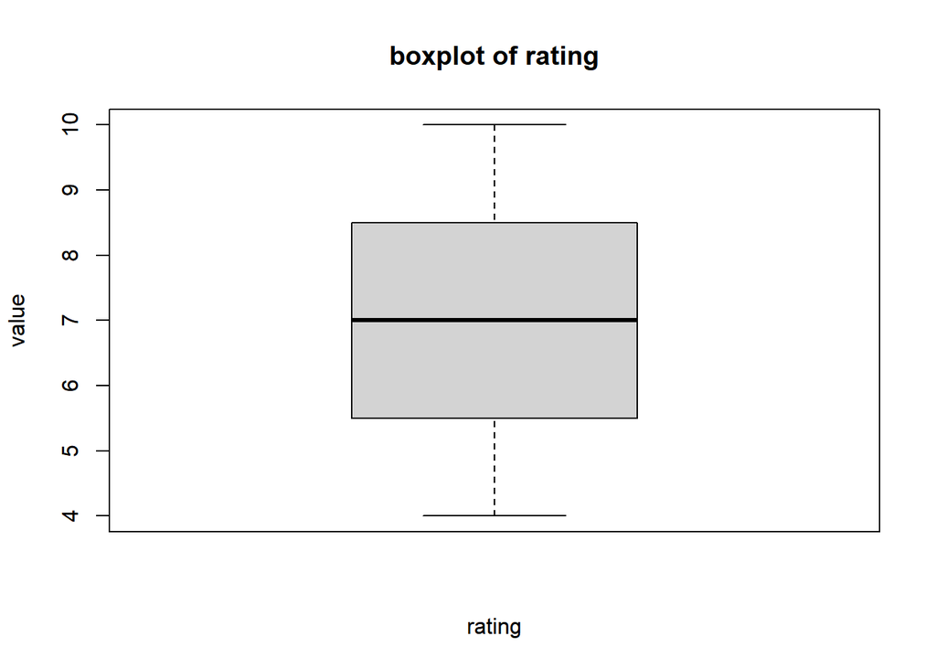

```r
boxplot(data$rating, main='boxplot of rating', xlab='rating', ylab='value')
```

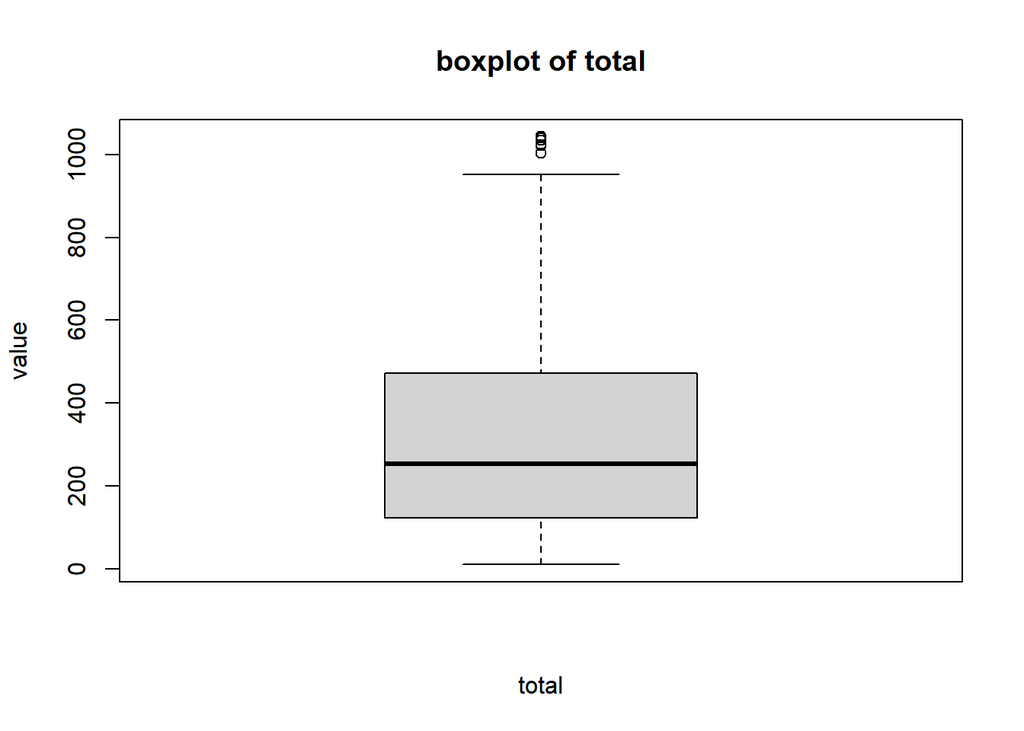

```r
boxplot(data$total, main='boxplot of total', xlab='total', ylab='value')
```

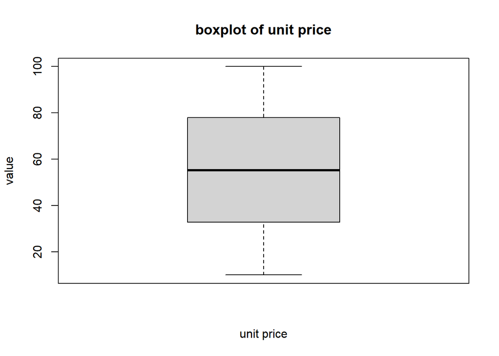

```r
boxplot(data$unit.price, main='boxplot of unit price', xlab='unit price', ylab='value')
```

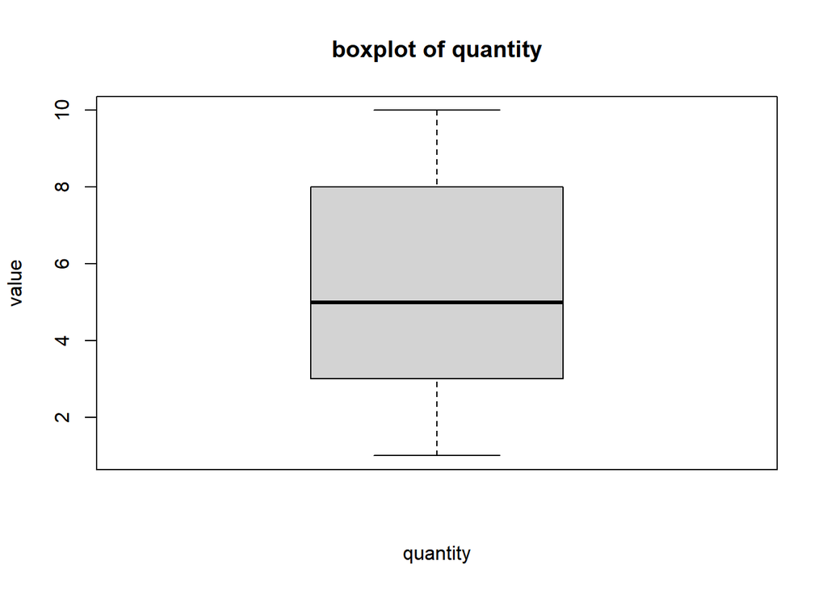

```r
boxplot(data$quantity, main='boxplot of quantity', xlab='quantity', ylab='value')
```

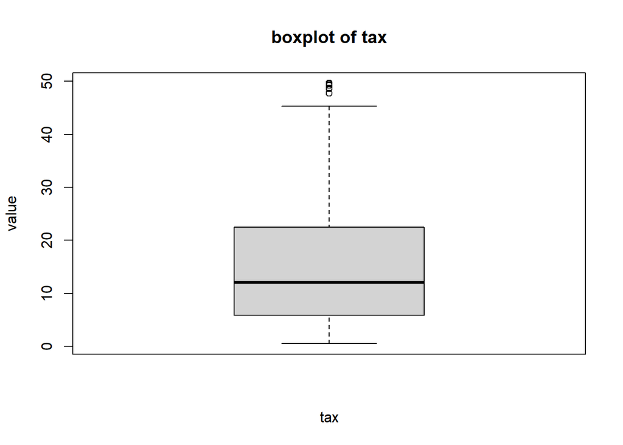

```r
boxplot(data$tax, main='boxplot of tax', xlab='tax', ylab='value')
```

`We'll not drop the outliers as they might give insight of the product sales made.`

# 5) Exploratory data analysis

## Univariate Analysis

```r
#measures of central tendency
#Finding the mean
mean <- colMeans(data[sapply(data, is.numeric)])
mean
```

```
##              unit.price                quantity                     tax
##               55.672130                5.510000               15.379369
##                    cogs gross.margin.percentage            gross.income
##              307.587380                4.761905               15.379369
##                  rating                   total
##                6.972700              322.966749
```

```r
#finding the median
library(tidyverse)
library(robustbase)
median <- data %>%
  select_if(is.numeric) %>%
  as.matrix() %>%
  colMedians()
median
```

```
##              unit.price                quantity                     tax
##               55.230000                5.000000               12.088000
##                    cogs gross.margin.percentage            gross.income
##              241.760000                4.761905               12.088000
##                  rating                   total
##                7.000000              253.848000
```

```r
#Finding the mode
mode <- function(v) {
  uniqv <- unique(v)
  uniqv[which.max(tabulate(match(v, uniqv)))]

}
```

```r
#Measures of dispersion
#Finding the minimum

min(data$cogs)
```

```
## [1] 10.17
```

```r
min(data$gross.margin.percentage)
```

```
## [1] 4.761905
```

```r
min(data$gross.income)
```

```
## [1] 0.5085
```

```r
min(data$rating)
```

```
## [1] 4
```

```r
min(data$total)
```

```
## [1] 10.6785
```

```r
min(data$unit.price)
```

```
## [1] 10.08
```

```r
min(data$quantity)
```

```
## [1] 1
```

```r
min(data$tax)
```

```
## [1] 0.5085
```

```r
#Finding the maximum
max(data$cogs)
```

```
## [1] 993
```

```r
max(data$gross.margin.percentage)
```

```
## [1] 4.761905
```

```r
max(data$gross.income)
```

```
## [1] 49.65
```

```r
max(data$rating)
```

```
## [1] 10
```

```r
max(data$total)
```

```
## [1] 1042.65
```

```r
max(data$unit.price)
```

```
## [1] 99.96
```

```r
max(data$quantity)
```

```
## [1] 10
```

```r
max(data$tax)
```

```
## [1] 49.65
```

```r
#Finding the range
range(data$cogs)
```

```
## [1]  10.17 993.00
```

```r
range(data$gross.margin.percentage)
```

```
## [1] 4.761905 4.761905
```

```r
range(data$gross.income)
```

```
## [1]  0.5085 49.6500
```

```r
range(data$rating)
```

```
## [1]  4 10
```

```r
range(data$total)
```

```
## [1]   10.6785 1042.6500
```

```r
range(data$unit.price)
```

```
## [1] 10.08 99.96
```

```r
range(data$quantity)
```

```
## [1]  1 10
```

```r
range(data$tax)
```

```
## [1]  0.5085 49.6500
```

```r
#Finding the quantiles
quantile(data$cogs)
```

```
##       0%      25%      50%      75%     100%
##  10.1700 118.4975 241.7600 448.9050 993.0000
```

```r
quantile(data$gross.margin.percentage)
```

```
##       0%      25%      50%      75%     100%
## 4.761905 4.761905 4.761905 4.761905 4.761905
```

```r
quantile(data$gross.income)
```

```
##        0%       25%       50%       75%      100%
##  0.508500  5.924875 12.088000 22.445250 49.650000
```

```r
quantile(data$rating)
```

```
##   0%  25%  50%  75% 100%
##  4.0  5.5  7.0  8.5 10.0
```

```r
quantile(data$total)
```

```
##        0%       25%       50%       75%      100%
##   10.6785  124.4224  253.8480  471.3502 1042.6500
```

```r
quantile(data$unit.price)
```

```
##     0%    25%    50%    75%   100%
## 10.080 32.875 55.230 77.935 99.960
```

```r
quantile(data$quantity)
```

```
##   0%  25%  50%  75% 100%
##    1    3    5    8   10
```

```r
quantile(data$tax)
```

```
##        0%       25%       50%       75%      100%
##  0.508500  5.924875 12.088000 22.445250 49.650000
```

```r
#Finding the variance
var(data$cogs)
```

```
## [1] 54838.64
```

```r
var(data$gross.margin.percentage)
```

```
## [1] 0
```

```r
var(data$gross.income)
```

```
## [1] 137.0966
```

```r
var(data$rating)
```

```
## [1] 2.953518
```

```r
var(data$total)
```

```
## [1] 60459.6
```

```r
var(data$unit.price)
```

```
## [1] 701.9653
```

```r
var(data$quantity)
```

```
## [1] 8.546446
```

```r
var(data$tax)
```

```
## [1] 137.0966
```

```r
#Finding the standard Deviation
sd(data$cogs)
```

```
## [1] 234.1765
```

```r
sd(data$gross.margin.percentage)
```

```
## [1] 0
```

```r
sd(data$gross.income)
```

```
## [1] 11.70883
```

```r
sd(data$rating)
```

```
## [1] 1.71858
```

```r
sd(data$total)
```

```
## [1] 245.8853
```

```r
sd(data$unit.price)
```

```
## [1] 26.49463
```

```r
sd(data$quantity)
```

```
## [1] 2.923431
```

```r
sd(data$tax)
```

```
## [1] 11.70883
```

```r
#Finding the Skewness
library(e1071)

skewness(data$cogs)
```

```
## [1] 0.8898939
```

```r
skewness(data$gross.margin.percentage)
```

```
## [1] NaN
```

```r
skewness(data$gross.income)
```

```
## [1] 0.8898939
```

```r
skewness(data$rating)
```

```
## [1] 0.008982638
```

```r
skewness(data$total)
```

```
## [1] 0.8898939
```

```r
skewness(data$unit.price)
```

```
## [1] 0.00705623
```

```r
skewness(data$quantity)
```

```
## [1] 0.01290225
```

```r
skewness(data$tax)
```

```
## [1] 0.8898939
```

```r
#Finding the kurtosis
kurtosis(data$cogs)
```

```
## [1] -0.09329206
```

```r
kurtosis(data$gross.margin.percentage)
```

```
## [1] NaN
```

```r
kurtosis(data$gross.income)
```

```
## [1] -0.09329206
```

```r
kurtosis(data$rating)
```

```
## [1] -1.155525
```

```r
kurtosis(data$total)
```

```
## [1] -0.09329206
```

```r
kurtosis(data$unit.price)
```

```
## [1] -1.222062
```

```r
kurtosis(data$quantity)
```

```
## [1] -1.219039
```

```r
kurtosis(data$tax)
```

```
## [1] -0.09329206
```

## Univariate data analysis Graphicals

### categorical data

```r
str(data)
```

```
## 'data.frame':    1000 obs. of  15 variables:
##  $ branch                 : chr  "A" "C" "A" "A" ...
##  $ customer.type          : chr  "Member" "Normal" "Normal" "Member" ...
##  $ gender                 : chr  "Female" "Female" "Male" "Male" ...
##  $ product.line           : chr  "Health and beauty" "Electronic accessories" "Home and lifestyle" "Health and beauty" ...
##  $ unit.price             : num  74.7 15.3 46.3 58.2 86.3 ...
##  $ quantity               : int  7 5 7 8 7 7 6 10 2 3 ...
##  $ tax                    : num  26.14 3.82 16.22 23.29 30.21 ...
##  $ date                   : chr  "1/5/2019" "3/8/2019" "3/3/2019" "1/27/2019" ...
##  $ time                   : chr  "13:08" "10:29" "13:23" "20:33" ...
##  $ payment                : chr  "Ewallet" "Cash" "Credit card" "Ewallet" ...
##  $ cogs                   : num  522.8 76.4 324.3 465.8 604.2 ...
##  $ gross.margin.percentage: num  4.76 4.76 4.76 4.76 4.76 ...
##  $ gross.income           : num  26.14 3.82 16.22 23.29 30.21 ...
##  $ rating                 : num  9.1 9.6 7.4 8.4 5.3 4.1 5.8 8 7.2 5.9 ...
##  $ total                  : num  549 80.2 340.5 489 634.4 ...
```

```r
#Frequency table of gender
gender_freq <- table(data$gender)
sort(gender_freq, decreasing = TRUE)[1:5]
```

```
##
## Female   Male   <NA>   <NA>   <NA>
##    501    499
```

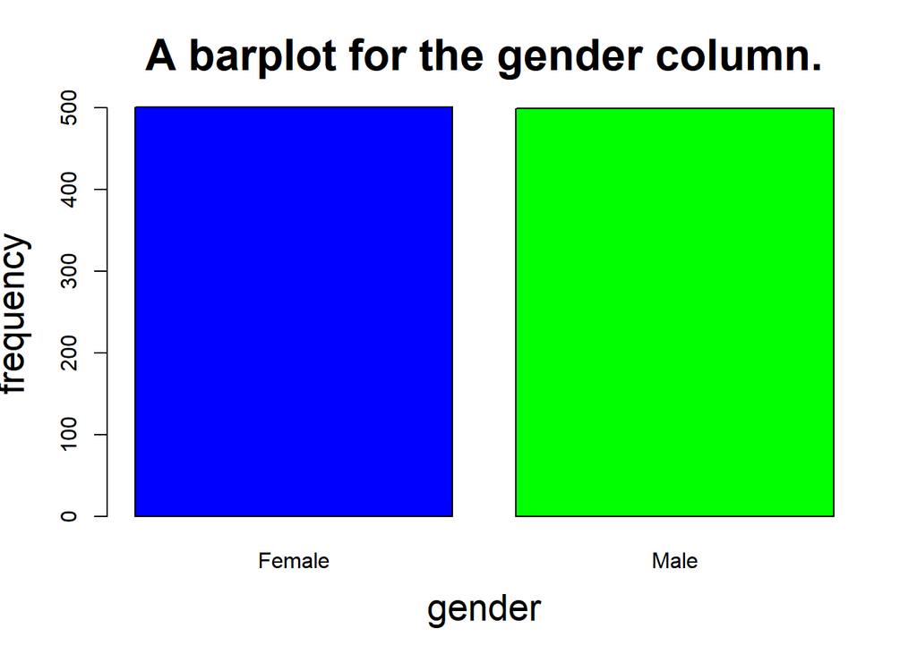

```r
#Bar graph to show frequency distribution of gender
options(repr.plot.width = 10, repr.plot.height = 10)
barplot(c(gender_freq), main="A barplot for the gender column.",
        xlab="gender",
        ylab="frequency",
        cex.main=2, cex.lab=1.7,cex.sub=1.2,
        width=c(30,30),
        col=c("blue","green"))
```

```r
#frequency table for customer type
customer_freq <- table(data$customer.type)
sort(customer_freq, decreasing = TRUE)[1:5]
```

```
##
## Member Normal   <NA>   <NA>   <NA>
##    501    499
```

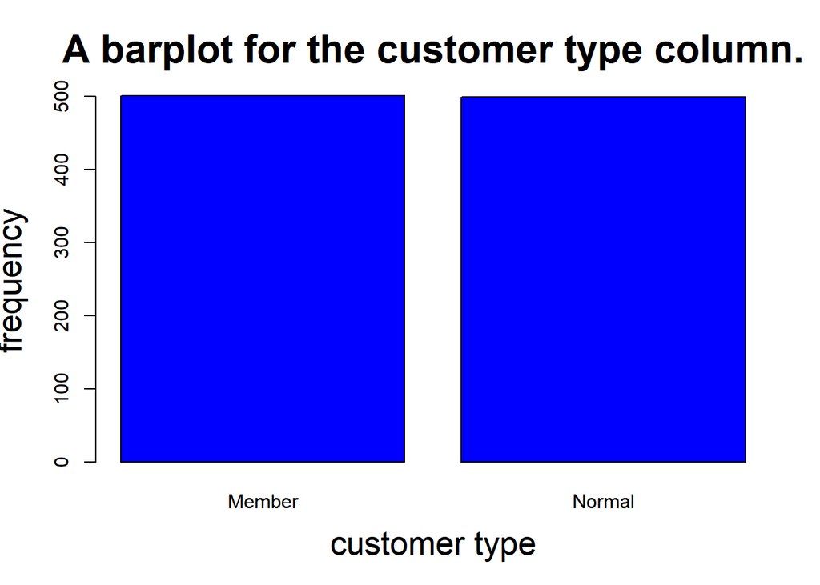

```r
#Bar graph to show frequency distribution of customer type
options(repr.plot.width = 10, repr.plot.height = 10)
barplot(c(customer_freq), main="A barplot for the customer type column.",
        xlab="customer type",
        ylab="frequency",
        cex.main=2, cex.lab=1.7,cex.sub=1.2,
        width=c(30,30),
        col=c("blue"))
```

```r
#frequency table for payment
pay_freq <- table(data$payment)
sort(pay_freq, decreasing = TRUE)[1:5]
```

```
##
##     Ewallet        Cash Credit card        <NA>        <NA>
##         345         344         311
```

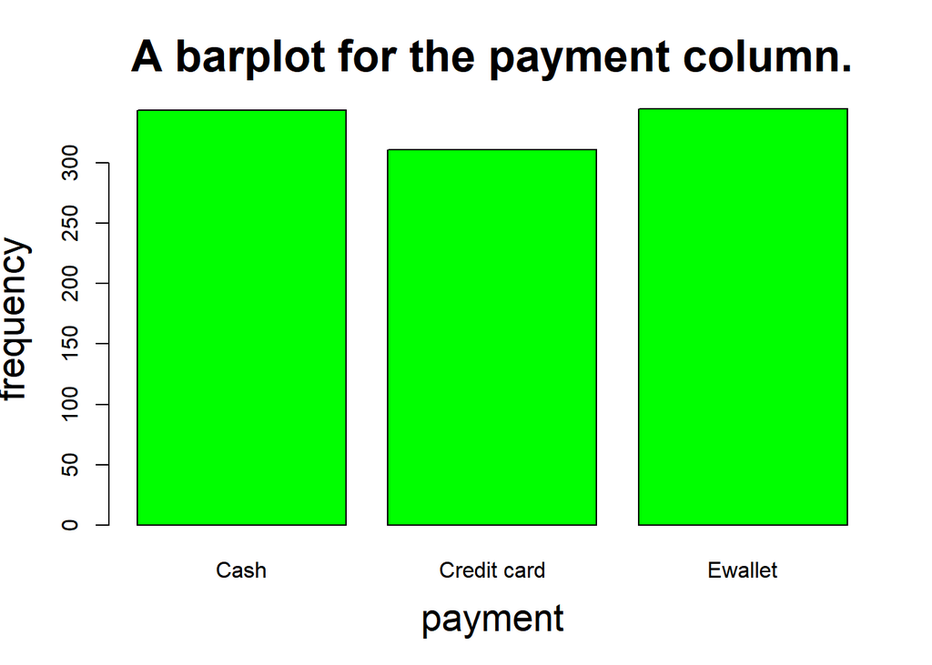

```r
#Bar graph to show frequency distribution of payment type
options(repr.plot.width = 10, repr.plot.height = 10)
barplot(c(pay_freq), main="A barplot for the payment column.",
        xlab="payment",
        ylab="frequency",
        cex.main=2, cex.lab=1.7,cex.sub=1.2,
        width=c(30,30),
        col=c("green"))
```

```r
#frequency table for product line
prod_freq <- table(data$product.line)
sort(prod_freq, decreasing = TRUE)[1:5]
```

```
##
##    Fashion accessories     Food and beverages Electronic accessories
##                    178                    174                    170
##      Sports and travel     Home and lifestyle
##                    166                    160
```

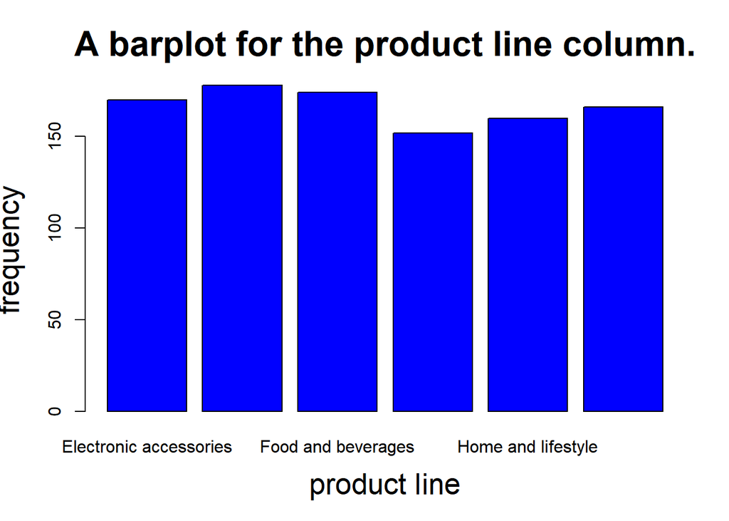

```r
#Bar graph to show frequency distribution of product line
options(repr.plot.width = 10, repr.plot.height = 10)
barplot(c(prod_freq), main="A barplot for the product line column.",
        xlab="product line",
        ylab="frequency",
        cex.main=2, cex.lab=1.7,cex.sub=1.2,
        width=c(30,30),
        col=c("blue"))
```

```r
#frequency table for branch
branch_freq <- table(data$branch)
sort(branch_freq, decreasing = TRUE)[1:5]
```

```
##
##    A    B    C <NA> <NA>
##  340  332  328
```

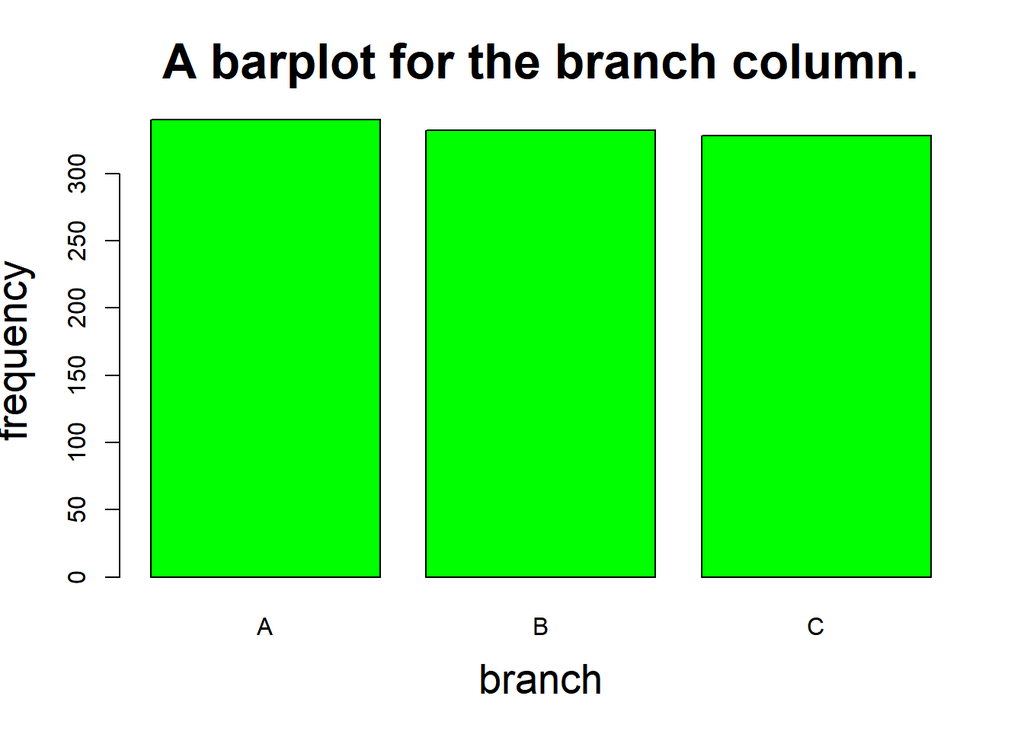

```r
#Bar graph to show frequency distribution of branch
options(repr.plot.width = 10, repr.plot.height = 10)
barplot(c(branch_freq), main="A barplot for the branch column.",
        xlab="branch",
        ylab="frequency",
        cex.main=2, cex.lab=1.7,cex.sub=1.2,
        width=c(30,30),
        col=c("green"))
```

### Numerical data

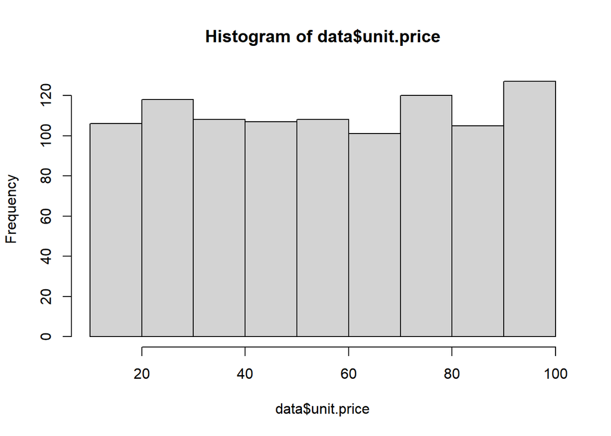

```r
#plotting histograms for numerical columns
hist(data$unit.price)
```

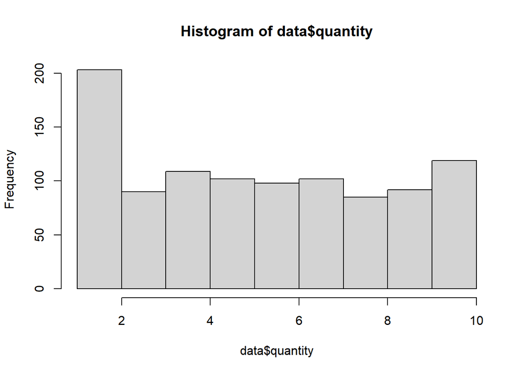

```r
hist(data$quantity)
```

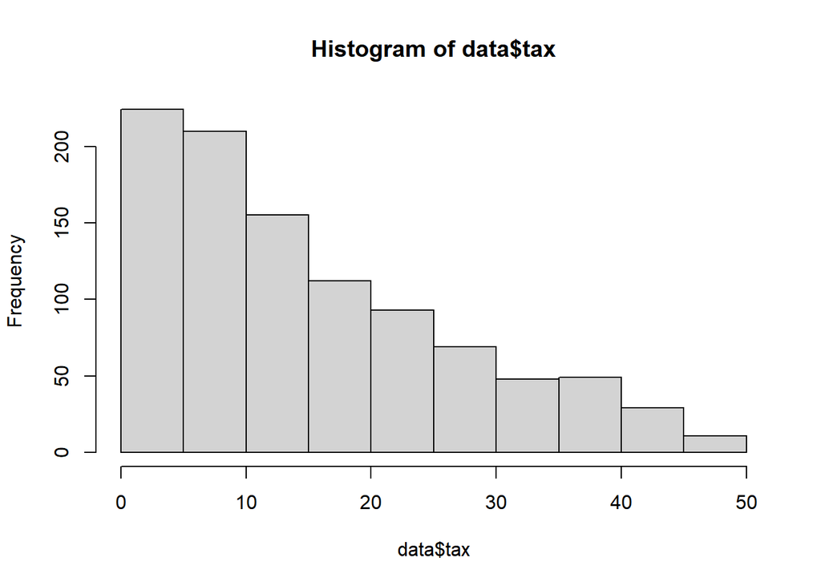

```r
hist(data$tax)
```

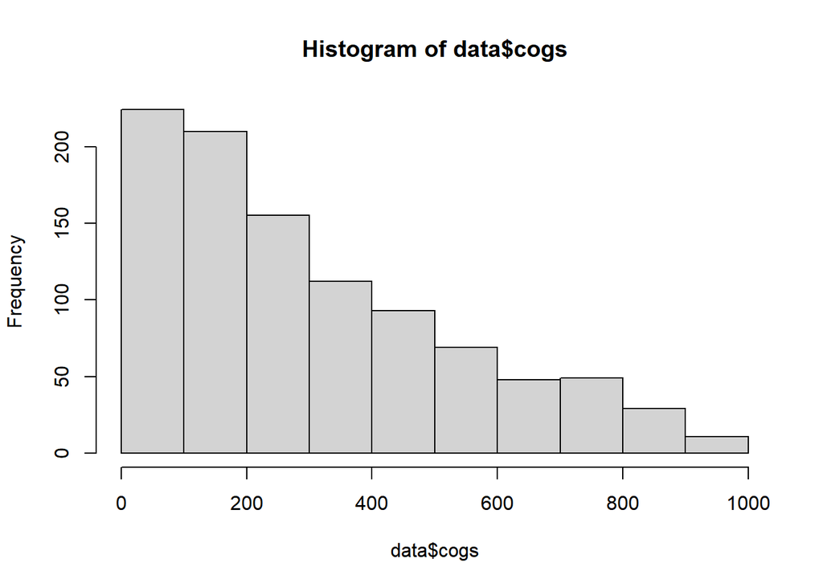

```r
hist(data$cogs)
```

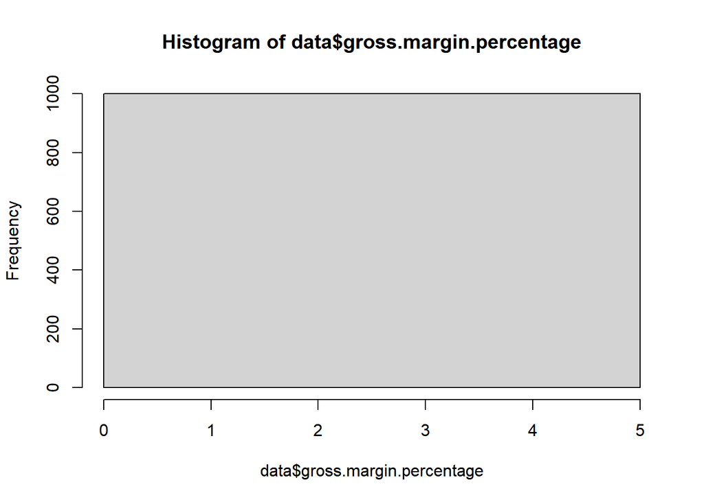

```r
hist(data$gross.margin.percentage)
```

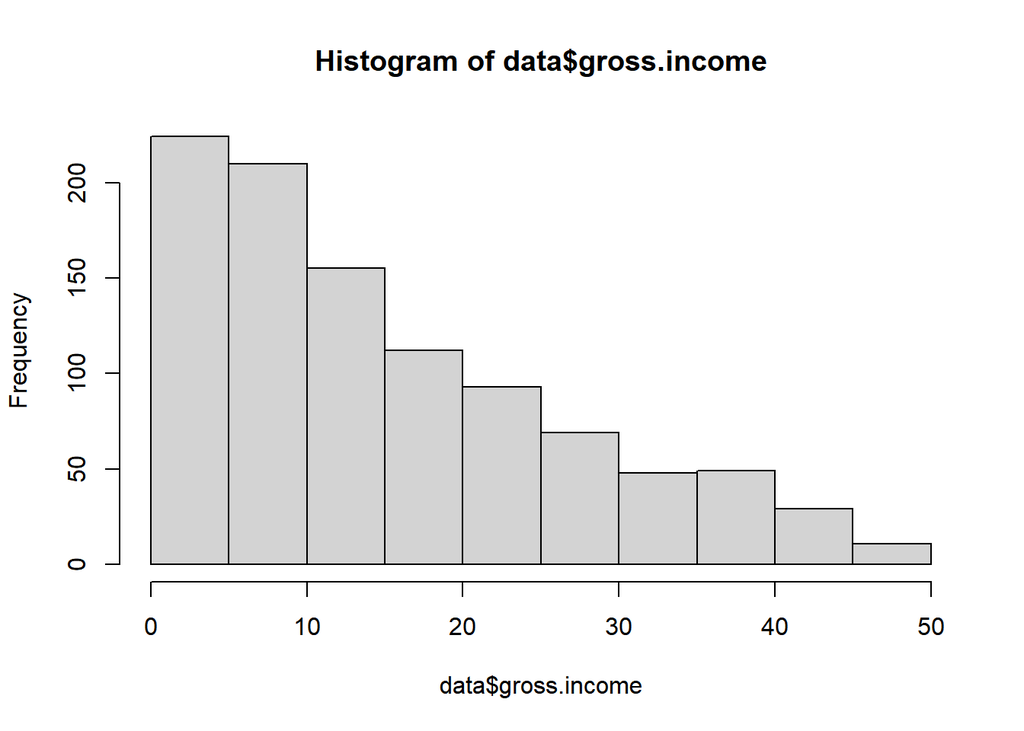

```r
hist(data$gross.income)
```

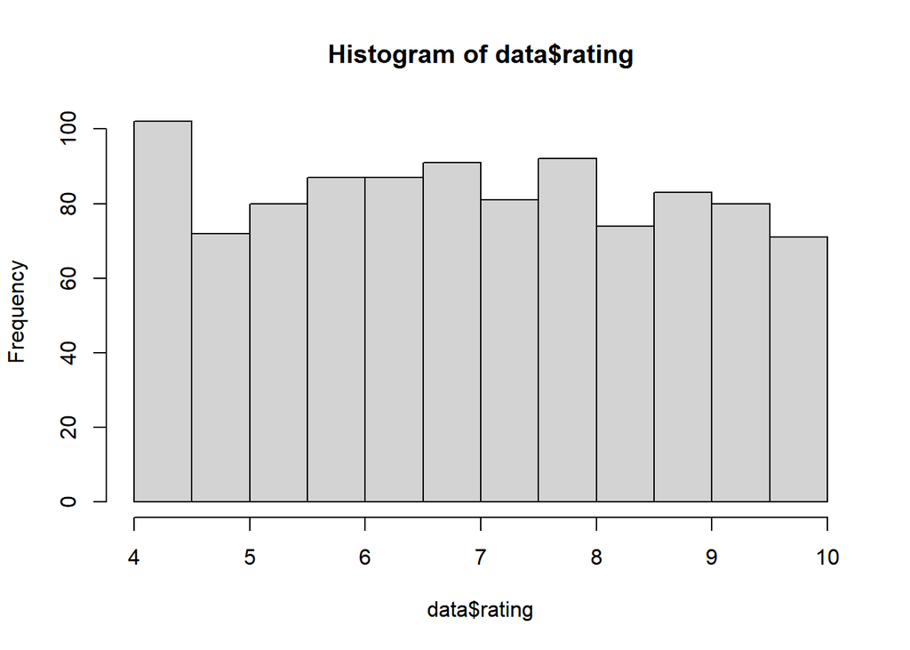

```r
hist(data$rating)
```

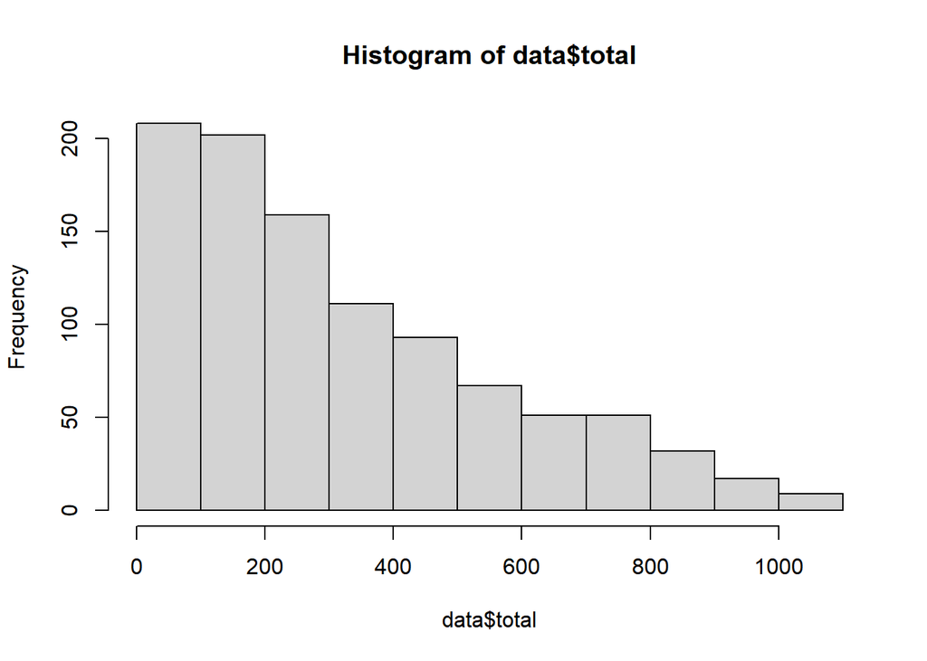

```r
hist(data$total)
```

### Observations from univariate analysis

- Females are more than males but only by 2.
- When it comes to customer tpes, members are more than the normal customers but only by 2.
- Most customers pay via EWallet followed by credit card and card
- The goods with most sales are fashion accessories, electronic accessories and food and food and beverages.
- Most data entries came from branch A followed by B and C.
- The total and cogs columns are positively skewed with most of the values concentrated to the left of the graph.

# 6) Bivariate and Multivariate analysis

```r
#covariance matrix
cov <- cov(data[sapply(data, is.numeric)])
round(cov,3)
```

```
##                         unit.price quantity      tax      cogs
## unit.price                 701.965    0.835  196.668  3933.367
## quantity                     0.835    8.546   24.150   482.991
## tax                        196.668   24.150  137.097  2741.932
## cogs                      3933.367  482.991 2741.932 54838.638
## gross.margin.percentage      0.000    0.000    0.000     0.000
## gross.income               196.668   24.150  137.097  2741.932
## rating                      -0.400   -0.079   -0.733   -14.666
## total                     4130.035  507.141 2879.028 57580.570
##                         gross.margin.percentage gross.income  rating     total
## unit.price                                    0      196.668  -0.400  4130.035
## quantity                                      0       24.150  -0.079   507.141
## tax                                           0      137.097  -0.733  2879.028
## cogs                                          0     2741.932 -14.666 57580.570
## gross.margin.percentage                       0        0.000   0.000     0.000
## gross.income                                  0      137.097  -0.733  2879.028
## rating                                        0       -0.733   2.954   -15.399
## total                                         0     2879.028 -15.399 60459.598
```

```r
#correlation matrix
cor <- cor(data[sapply(data, is.numeric)])
round(cor, 3)
```

```
##                         unit.price quantity    tax   cogs
## unit.price                   1.000    0.011  0.634  0.634
## quantity                     0.011    1.000  0.706  0.706
## tax                          0.634    0.706  1.000  1.000
## cogs                         0.634    0.706  1.000  1.000
## gross.margin.percentage         NA       NA     NA     NA
## gross.income                 0.634    0.706  1.000  1.000
## rating                      -0.009   -0.016 -0.036 -0.036
## total                        0.634    0.706  1.000  1.000
##                         gross.margin.percentage gross.income rating  total
## unit.price                                   NA        0.634 -0.009  0.634
## quantity                                     NA        0.706 -0.016  0.706
## tax                                          NA        1.000 -0.036  1.000
## cogs                                         NA        1.000 -0.036  1.000
## gross.margin.percentage                       1           NA     NA     NA
## gross.income                                 NA        1.000 -0.036  1.000
## rating                                       NA       -0.036  1.000 -0.036
## total                                        NA        1.000 -0.036  1.000
```

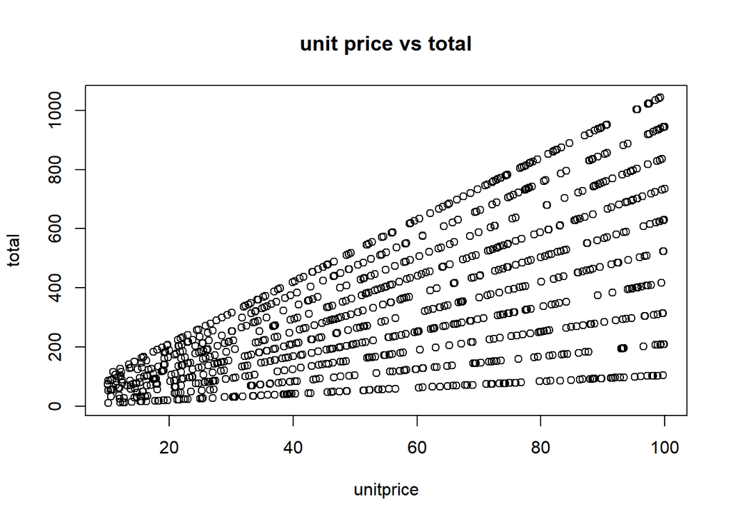

```r
#plotting scatter plots
#scatter plot between unitprice and total
unitp <- data$unit.price
t <- data$total
plot(unitp, t, main='unit price vs total', xlab='unitprice', ylab='total')
```

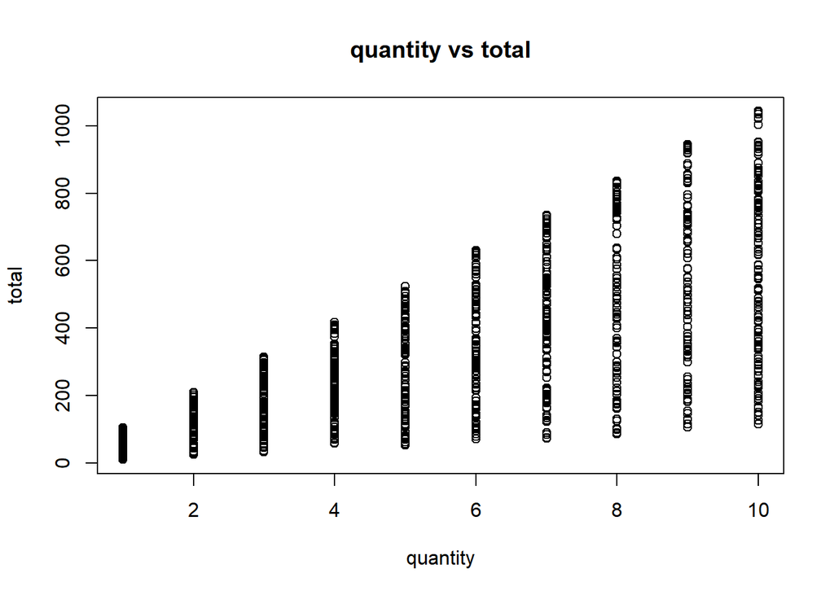

```r
#scatter plot between quantity and total
plot(data$quantity, data$total, main='quantity vs total', xlab='quantity', ylab='total')
```

[figure not shown]

```r
#scatter plot between tax and total
plot(data$tax, main='tax vs total', xlab='tax', ylab='total')
```

[figure not shown]

```r
#scatter plot of cogs and total
plot(data$cogs, main='cogs vs total', xlab='cogs', ylab='total')
```

[figure not shown]

```r
#scatter plot of gross margin percentage and total
plot(data$gross.margin.percentage, main='gross margin percentage vs total', xlab='gross margin percentage', ylab='total')
```

[figure not shown]

```r
#scatter plot of gross income and total
plot(data$gross.income, main='gross income vs total', ylab='total')
```

[figure not shown]

```r
#scatter plot of rating and total
plot(data$rating, main='rating vs total', xlab='rating', ylab='total')
```

# 7) Implementing the solution

## Dimentionality Reduction: PCA

```r
#selecting the numerical columns and removing the gross margin percentage column due to its 0 variance

str(data)
```

```
## 'data.frame':    1000 obs. of  15 variables:
##  $ branch                 : chr  "A" "C" "A" "A" ...
##  $ customer.type          : chr  "Member" "Normal" "Normal" "Member" ...
##  $ gender                 : chr  "Female" "Female" "Male" "Male" ...
##  $ product.line           : chr  "Health and beauty" "Electronic accessories" "Home and lifestyle" "Health and beauty" ...
##  $ unit.price             : num  74.7 15.3 46.3 58.2 86.3 ...
##  $ quantity               : int  7 5 7 8 7 7 6 10 2 3 ...
##  $ tax                    : num  26.14 3.82 16.22 23.29 30.21 ...
##  $ date                   : chr  "1/5/2019" "3/8/2019" "3/3/2019" "1/27/2019" ...
##  $ time                   : chr  "13:08" "10:29" "13:23" "20:33" ...
##  $ payment                : chr  "Ewallet" "Cash" "Credit card" "Ewallet" ...
##  $ cogs                   : num  522.8 76.4 324.3 465.8 604.2 ...
##  $ gross.margin.percentage: num  4.76 4.76 4.76 4.76 4.76 ...
##  $ gross.income           : num  26.14 3.82 16.22 23.29 30.21 ...
##  $ rating                 : num  9.1 9.6 7.4 8.4 5.3 4.1 5.8 8 7.2 5.9 ...
##  $ total                  : num  549 80.2 340.5 489 634.4 ...
```

```r
num <- data[sapply(data, is.numeric)]
num$gross.margin.percentage <- NULL
num
```

```
##      unit.price quantity     tax   cogs gross.income rating     total
## 1         74.69        7 26.1415 522.83      26.1415    9.1  548.9715
## 2         15.28        5  3.8200  76.40       3.8200    9.6   80.2200
## 3         46.33        7 16.2155 324.31      16.2155    7.4  340.5255
## 4         58.22        8 23.2880 465.76      23.2880    8.4  489.0480
## 5         86.31        7 30.2085 604.17      30.2085    5.3  634.3785
## 6         85.39        7 29.8865 597.73      29.8865    4.1  627.6165
## 7         68.84        6 20.6520 413.04      20.6520    5.8  433.6920
## 8         73.56       10 36.7800 735.60      36.7800    8.0  772.3800
## 9         36.26        2  3.6260  72.52       3.6260    7.2   76.1460
## 10        54.84        3  8.2260 164.52       8.2260    5.9  172.7460
## 11        14.48        4  2.8960  57.92       2.8960    4.5   60.8160
## 12        25.51        4  5.1020 102.04       5.1020    6.8  107.1420
## 13        46.95        5 11.7375 234.75      11.7375    7.1  246.4875
## 14        43.19       10 21.5950 431.90      21.5950    8.2  453.4950
```

[output cut: 986 more lines]

```r
#applying PCA
data.pca <- prcomp(num, center=TRUE, scale=TRUE)
data.pca
```

```
## Standard deviations (1, .., p=7):
## [1] 2.218512e+00 1.000200e+00 9.938793e-01 3.000112e-01 2.981082e-16
## [6] 1.492941e-16 9.831064e-17
##
## Rotation (n x k) = (7 x 7):
##                      PC1          PC2          PC3         PC4           PC5
## unit.price   -0.29176275  0.270866890 -0.693584569  0.60037161  6.582429e-16
## quantity     -0.32452880 -0.212748396  0.633152868  0.66972877  7.430508e-16
## tax          -0.44977957  0.004196356  0.001836202 -0.21835146 -8.277641e-01
## cogs         -0.44977957  0.004196356  0.001836202 -0.21835146  9.549992e-02
## gross.income -0.44977957  0.004196356  0.001836202 -0.21835146  2.290536e-01
## rating        0.01867926  0.938775165  0.343575909 -0.01754621 -1.194541e-17
## total        -0.44977957  0.004196356  0.001836202 -0.21835146  5.032105e-01
##                        PC6           PC7
## unit.price    5.894232e-17 -7.635490e-17
## quantity      1.864419e-16 -1.721827e-16
## tax           1.656386e-02  2.540320e-01
## cogs         -5.810190e-01 -6.350565e-01
## gross.income  7.836445e-01 -2.888526e-01
## rating        1.850076e-17 -7.208985e-17
## total        -2.191893e-01  6.698770e-01
```

```r
summary(data.pca)
```

```
## Importance of components:
##                           PC1    PC2    PC3     PC4       PC5       PC6
## Standard deviation     2.2185 1.0002 0.9939 0.30001 2.981e-16 1.493e-16
## Proportion of Variance 0.7031 0.1429 0.1411 0.01286 0.000e+00 0.000e+00
## Cumulative Proportion  0.7031 0.8460 0.9871 1.00000 1.000e+00 1.000e+00
##                              PC7
## Standard deviation     9.831e-17
## Proportion of Variance 0.000e+00
## Cumulative Proportion  1.000e+00
```

```r
#structure of our pca object
str(data.pca)
```

```
## List of 5
##  $ sdev    : num [1:7] 2.22 1.00 9.94e-01 3.00e-01 2.98e-16 ...
##  $ rotation: num [1:7, 1:7] -0.292 -0.325 -0.45 -0.45 -0.45 ...
##   ..- attr(*, "dimnames")=List of 2
##   .. ..$ : chr [1:7] "unit.price" "quantity" "tax" "cogs" ...
##   .. ..$ : chr [1:7] "PC1" "PC2" "PC3" "PC4" ...
##  $ center  : Named num [1:7] 55.67 5.51 15.38 307.59 15.38 ...
##   ..- attr(*, "names")= chr [1:7] "unit.price" "quantity" "tax" "cogs" ...
##  $ scale   : Named num [1:7] 26.49 2.92 11.71 234.18 11.71 ...
##   ..- attr(*, "names")= chr [1:7] "unit.price" "quantity" "tax" "cogs" ...
##  $ x       : num [1:1000, 1:7] -2.005 2.306 -0.186 -1.504 -2.8 ...
##   ..- attr(*, "dimnames")=List of 2
##   .. ..$ : NULL
##   .. ..$ : chr [1:7] "PC1" "PC2" "PC3" "PC4" ...
##  - attr(*, "class")= chr "prcomp"
```

```r
#visualizing our pca object
library(devtools)
```

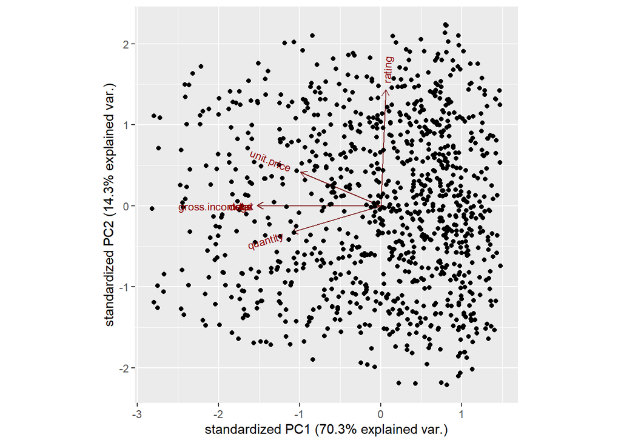

```r
library(ggbiplot)
ggbiplot(data.pca)
```

# 8) Feature Selection

```r
#1) Filter method

library(caret)
```

```r
library(corrplot)
corr.mat <- cor(num)
high.corr <- findCorrelation(corr.mat, cutoff=0.75)

#columns that are highly correlated
names(num[, high.corr])
```

```
## [1] "cogs"  "total" "tax"
```

```r
#removing the highly correlated variables
data2 <- num[-high.corr]
data2
```

```
##      unit.price quantity gross.income rating
## 1         74.69        7      26.1415    9.1
## 2         15.28        5       3.8200    9.6
## 3         46.33        7      16.2155    7.4
## 4         58.22        8      23.2880    8.4
## 5         86.31        7      30.2085    5.3
## 6         85.39        7      29.8865    4.1
## 7         68.84        6      20.6520    5.8
## 8         73.56       10      36.7800    8.0
## 9         36.26        2       3.6260    7.2
## 10        54.84        3       8.2260    5.9
## 11        14.48        4       2.8960    4.5
## 12        25.51        4       5.1020    6.8
## 13        46.95        5      11.7375    7.1
## 14        43.19       10      21.5950    8.2
```

[output cut: 986 more lines]

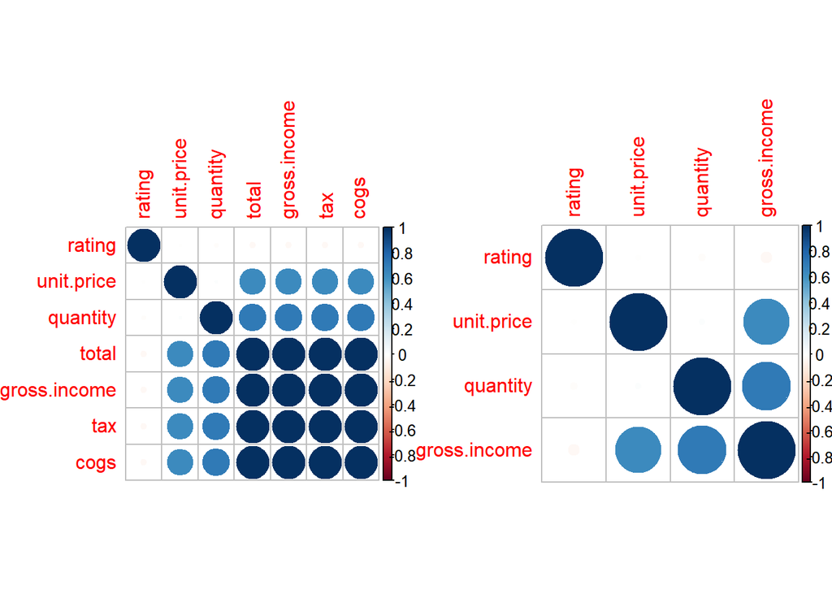

```r
# plotting heat maps for comparison
par(mfrow = c(1, 2))
corrplot(corr.mat, order = "hclust")
corrplot(cor(data2), order = "hclust")
```

```r
#Wrapper methods
library (clustvarsel)
```

```
## Package 'mclust' version 5.4.7
```

```
## Package 'clustvarsel' version 2.3.4
```

```r
library(mclust)

out <- clustvarsel(num)

Subset1 = num[,out$subset]
mod = Mclust(Subset1)
summary(mod)
```

```
## ----------------------------------------------------
## Gaussian finite mixture model fitted by EM algorithm
## ----------------------------------------------------
##
## Mclust EVV (ellipsoidal, equal volume) model with 7 components:
##
##  log-likelihood    n df       BIC       ICL
##       -10478.95 1000 63 -21393.08 -21446.89
##
## Clustering table:
##   1   2   3   4   5   6   7
## 173 134 126 148 128 142 149
```

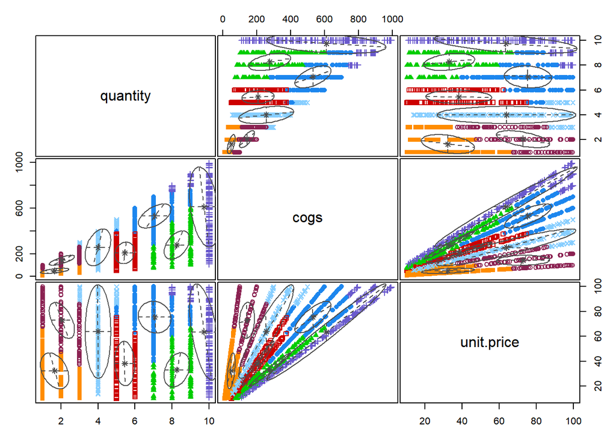

```r
plot(mod,c("classification"))
```

## Conclusion

- Principal component analysis does a great job in dimensionality reduction as the first 3 Principal components, out of 7, explain 98% of the variance in the data.
- Tax, cogs, gross income and total are the largest contributors to PC1.
- Rating , unit price and quantity are largest contributors to PC2.
- Unit price, quantity and rating are the highest contributors to PC3.
- Feature selection gave 4 variables: Unit price, quantity, gross income and ratings infering that these 4 variables would suffice in creating an accurate predictive model leading to maximizing of sales made.